# Section B. Project Workplan

Author

Miao Li

## Part 1. Community-Driven Investments for Change (80 total)

### 1.1 Community Vision Description (10 points)

#### 1.1.1 Community Description: (3 points)

*(describe the community’s resources, assets, local community characteristics, and the type of benefits the grants will provide to the community.)*.

The Berkeley Lake Moultrie (BLM) Area is a 526-square-mile region forming a ring around Lake Moultrie, located in the remote northwestern corner of Berkeley County, South Carolina. Sparsely populated with approximately 40,000 residents spread across 3 towns and 6 unincorporated communities, the area is bordered by another lake and the Santee River wetlands to the north, the Francis Marion National Forest to the east, swamps and woodlands to the west, and suburban communities of the Charleston metropolitan area to the south. Geographic constraints have concentrated human settlement, economic activities, and transportation within this ring around Lake Moultrie. The natural barriers on three sides, combined with the lake at the center, have resulted in the region being predominantly rural and significantly underserved. The population density is 75/mi<sup>2</sup>, which is well below the national average (98/mi<sup>2</sup>). According to the EJScreen tool, half of the 26 census block groups in the BLM Area are classified as disadvantaged communities, with the remaining block groups skewed by the presence of small clusters of lake houses.

Communities in the BLM area possess some important resources that offer a foundation for building resilience. Highways and local road networks around the lake provide critical routes for emergency evacuation. Over 100 public access buildings, well-connected by these roads, offer essential social support. These include 105 faith-based organizations, 30 charitable and nonprofit groups, 3 community centers, 3 public libraries, 2 town halls, 3 fire departments, 3 parks and recreation centers, and 1 civic center. The **Trident United Way**, with its long-established partnerships with **Volunteer Organizations Active in Disaster (VOAD)** and other CBOs, has already laid important groundwork for community mobilization and service delivery. For instance, the Berkeley Resource Connection Center, operated by TUW, plays a vital role in coordinating local social services and disaster relief efforts. Additionally, Berkeley Electric Cooperative, the largest not-for-profit electric cooperative in South Carolina that serves much of the area, has extensive experience in serving and upgrading energy-inefficient homes. While these resources alone may not be sufficient to address all of the area’s needs, they can be leveraged with additional support to create more resilient and empowered communities.

Moreover, this area is brimming with green energy opportunities that can benefit the local disadvantaged population. With 4.5 to 5 hours of peak sun daily, the area is ideal site for expanding solar energy production in residential and public buildings. The fastly growing solar panel manufacturing industry in South Carolina further support this potential. The area also boasts affordable land and convenient access to the Charleston metropolitan economic hub, home to one of the busiest and most important ports in the U.S., via three southbound traffic arteries: US Highway 52 (US-52), US Highway 176 (US-176), and US Highway 17 Alternate (US 17 Alt). Moreover, a large portion of the BLM area was designated by the Governor as the Opportunity Zone that offers aggressive tax incentives to attract clean energy and advanced manufacturing businesses. The 4,000-acre Camp Hall Commerce Park on the area’s southern border already hosts major employers like Volvo Cars, BSS Global Inc., and Redwood Materials, with potential to generate thousands of jobs that reduce GHG emissions and air pollutants. The Commerce Park is quickly attracting more investors aligned with its vision of a next-generation industry park. These developments happen within the broader context of South Carolina’s rapidly growing into a hub for clean energy supply chain, including electric vehicle and battery manufacturing, solar panel production, and advanced materials manufacturing.

By building resilient infrastructure, promoting clean energy use, reducing pollution, fostering a healthy school environment, and launching a robust workforce development initiative that connects schools with the local green energy industry, the local communities stand to gain in several ways: a reduced energy burden, a healthier living environment, improved educational outcomes as schools adopt industry-relevant skills, better job opportunities through direct employment in the expanding green energy sector,long-term economic stability, enhanced quality of life for residents, and greater community resilience during extreme weather events and disasters.

#### 1.1.2 Community Challenges: (4 points)

*(Describe the needs and challenges the community in the Project Area is facing, including climate impacts, climate change risks / exposures, and / or localized pollution. Describe the impact of these challenges on the community, and particularly on priority populations within the Project Area who are acutely exposed to and impacted by climate, pollution, and weather-related threats, and / or who exhibit acute vulnerabilities or susceptibilities to the impacts of environmental pollution.)*.

Despite the great potential, communities in the BLM area grapple with multiple mutually reinforcing challenges, including socioeconomic vulnerability, climate and environmental hazards, inadequate infrastructure and high energy burden, workforce development crisis, and health disparities. Over 40% of residents live in low-income households, and 42% of the population is African American. The area also has a significant aging population (20%) and a high disability rate (17%). Nine of the 12 public schools that serve over 5,900 students are Title I schools with high poverty rates. Additionally, most communities in of the region are located in an USDA defined food desert, with obesity rates ranging from 42% to 52%.

Beyond socioeconomic vulnerabilities, the BLM area faces a range of **climate impacts and environmental risks** that threaten community wellbeing. Communities in the areas in general have *high* or *very high* National Risk Rating but *moderate* to *low* Community Resilience Rating. In terms of the climate, the region on average has over 80 days of extreme heat (>90 F) per year. Nearly 60% of the region faces high wildfire risks (rated as top 10% nationally). With over 7% of the area in a 100-year floodplain, communities are highly vulnerable to flooding events, particularly as climate change increases the frequency and severity of such occurrences. The area’s high exposure to hurricanes and lightning adds to the vulnerability: [11 hurricanes and 5 tropical storms](https://www.dnr.sc.gov/climate/sco/hurricanes/#map) have struck in the past 20 years, causing significant damage and disrupting lives. Other than strong winds and precipitation from hurricanes and tropic storms, the average annualized frequency of lightening in this area exceeds 95 times/yr, posing significant threat to stable energy supply.

Adding to these climate hazards is the localized pollution from nearby industrial facilities. Facilities like the Holcim Holly Hill Cement Plant and Santee Cooper Cross Generating Station, among others, contribute to toxic air emissions, placing this the region among the top 16% of areas nationwide in terms of toxic release to air. One of the schools with severely outdated HVAC systems, which we propose to replace, is only 2.5 miles away from Santee Cooper Cross Generating Station, a major coal-fired power plant in South Carolina. Respiratory health outcomes in the area are already concerning, with asthma affecting over 11% of the population. South Carolina’s aggressive industrial expansion, coupled with minimal environmental regulation and oversight, is likely to worsen these conditions and elevate health risks. Water pollution is another pressing issue in the area. Due to its rural status, most residents lack access to municipal water and sewer services, relying instead on septic tanks and wells for their water needs. However, limited financial resources and high poverty rates prevent many households from affording regular septic tank maintenance. As a result, septic tank leaks are frequent, often contaminating nearby drinking wells.

The region’s **inadequate infrastructure and high energy burdens** can further compound these environmental and climate challenges. The lack of a regional resilience hub, along with public shelters that lack resilient power supplies and energy-efficient air filtration systems, means that even designated emergency shelters are often unable to provide a safe haven during crises. The residential housing stock is similarly vulnerable: nearly half of the 12,000 housing units are mobile homes with poor insulation and outdated utilities, contributing to low energy efficiency. On average, low-income households (<= 150% FPL) spend 12% of their income on energy needs, with some spending up to 20%. Around 15% of low-income households in the area still rely on wood for heating. Only a third of low-income households use electricity as their primary heating source. The intersection of economic hardship, poor infrastructure, and environmental risks means that without targeted intervention, priority populations in the BLM area will continue to face disproportionate impacts from climate change, pollution, and extreme weather events.

Last but not least, the BLM area is experiencing a **workforce development crisis**, which prevents a sustainable economic growth that can help address the local challenges. High poverty rates and limited school resources result in only 20% of high school students being college-ready, and less than 40% career-ready. Less than 11% of high school students have completed a Career and Technical Education (CTE) program or earned industry-recognized certifications. Prospects for the future workforce remain bleak, with less than 15% of middle schoolers meeting expectations in math, 22% in science, and 36% in English. This weak workforce pipeline starkly contrasts with above-mentioned burgeoning green industrial development opportunities both locally and across South Carolina. A well planned and coordinated workforce development strategy connecting high schools with local industries can thus bridge this critical gap and support local economic growth.

#### 1.1.3 Community Vision: (3 points)

*(Articulate a vision for the impact and benefits the grant would have on the community in the near and long term, including the effect it will have on reducing and preventing pollution; building resilience to climate change and mitigating current and future climate risks;; creating high-quality jobs and expanding economic opportunity through workforce development; and bolstering community strength by insuring that local residents receive the benefits of investments and have the opportunity to build on them for current and future generations. )*.

We plan to use the grant to support strategies that build climate resilience, improve energy efficiency, and foster economic growth in the BLM community. These strategies include establishing a network of community resilience hubs powered by renewable energy and storage systems, replacing outdated HVAC systems and installing air purification systems in schools, and launching a workforce development program that aligns local high school curricula with industry needs. Additionally, the grant will fund weatherization and energy efficiency upgrades for 250 low-income households and provide solar panel installations to reduce energy costs and enhance energy resilience for residents.

These strategies will deliver both immediate and long-term benefits to the BLM communities by addressing critical needs, reducing pollution, and fostering economic growth. In the short term, replacing outdated HVAC systems and installing air purification in schools will improve air quality, benefiting children. Weatherization and energy efficiency upgrades for 250 low-income households, along with solar panel installations, will reduce energy costs and emissions, easing the financial burden on families. The workforce development program will align high school training with industry needs, creating pathways to well-paying jobs in the clean energy sector.

Long-term, the establishment of community resilience hubs powered by renewable energy will enhance the community’s ability to withstand climate-related disruptions, ensuring access to essential services during emergencies. This, along with a sustained focus on clean energy, will reduce the region’s carbon footprint and promote environmental sustainability. The workforce initiative will ensure that new job opportunities remain local, attracting further investment and creating a stable economic base. By directly involving residents in these efforts, the grant will empower the community to thrive, ensuring that the benefits of these investments are felt across generations.

### 1.2 Selected Strategies: (45 points total).

#### 1.2.1 Strategy Overview – (15 points)

Partnering with community-based organizations (CBOs) and the school district, we propose a comprehensive plan to build community resilience, improve school health, and foster long-term economic growth in the Berkeley Lake Moultrie (BLM) community. Our climate action plan includes establishing a network of community resilience hubs equipped with renewable energy and energy storage systems. These hubs will strengthen the community’s ability to withstand climate-related disruptions by ensuring access to essential services such as food, water, communication, financial assistance, and healthcare during emergencies. Additionally, we will perform energy efficiency upgrades for 250 low-income households and install solar panels to reduce energy costs and improve energy resilience. To support workforce development, we will align high school curricula with local industry needs, preparing students for careers in the clean energy sector that is quickly expanding in the area. As part of our pollution reduction plan, we will upgrade outdated HVAC systems and install air purification systems in schools to improve indoor air quality. These concerted efforts aim to help the community effectively cope with the growing challenges of climate change and air pollution, and better prepared to seize economic opportunities in the energy transition, rather than being left behind..

The requested funding amount for each strategy and associated project was determined based on the scope of work, cost of technology and installation, and projected community benefits. To ensure the effectiveness of our approach, we will allocate 70% of the funding to climate action, 20% to pollution reduction efforts, and the remaining 10% to community engagement and collective action building. Our strategies will be guided by research-based methods and multidisciplinary approaches to ensure measurable improvements in resilience, environmental quality, and public health. Through a focus on community-specific needs and systematic evaluation, we aim to address the social and infrastructural barriers that contribute to disparities in energy security, health, and resilience. This project will not only enhance the community’s ability to adapt to climate risks but also empower residents to take part in a sustainable future. Figure 1 maps out our strategies by type, implementation site, and budget size.

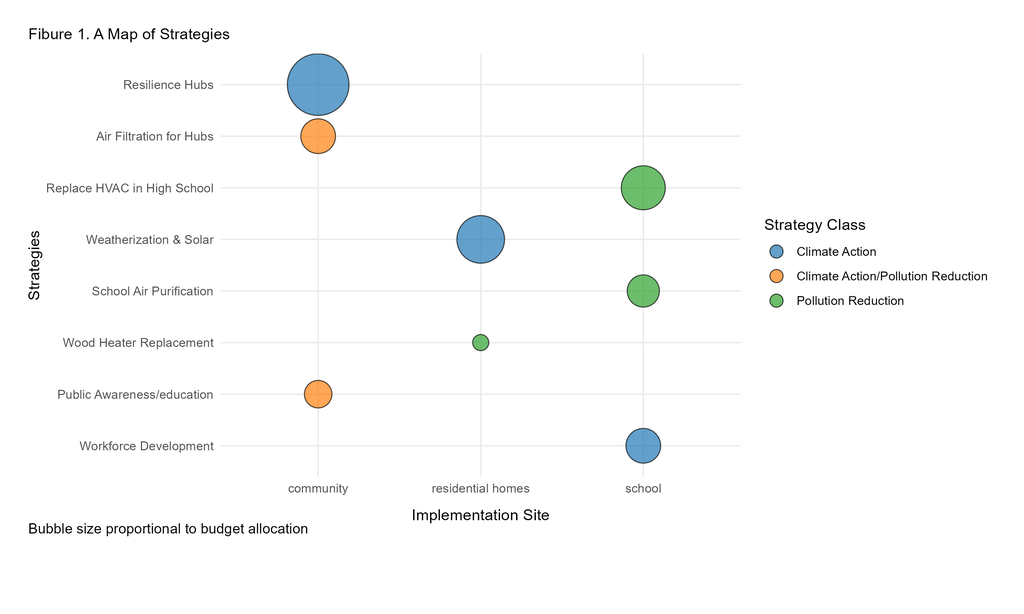

### 1.3 Community Engagement and Collaborative Governance Plan: (15 points)

### 1.4 Community Strength Plan: (10 points)